# Análisis genómicos y transcriptómicos con plataforma NGS

Tabla de Contenidos

- Lecturas cortas *‘short reads’*
  - fasta
  - fastq
- Alineamiento frente a genoma de referencia
  - alineamiento
  - indexar genoma de referencia
  - mapear lecturas (`.fastq`)
  - `.sam` -> `.bam`
- Análisis de Expresión Diferencial
  - alineamiento
  - gene quantification
  - DESeq workflow
    - organize the data
    - DESeq2 object
    - normalize raw counts

Enlaces R & Bioconductor

- [Central R Archive Network (CRAN)](http://cran.rstudio.com/)
- [RStudio](http://www.rstudio.com/)
- [Bioconductor](http://bioconductor.org/install)

## Instalación de paquetes

### Instalación de paquetes desde CRAN

```
install.packages("R.utils")       # <- uncompress .gz files
install.packages("BiocManager")   # <- Bioconductor manager
```

### Instalación de Bioconductor

```
BiocManager::install()
```

Podemos saber la version de Bioconductor que estamos usando y si los paquetes están actualizados:

```
BiocManager::version()
BiocManager::valid()
```

Los módulos de trabajo son lo siguientes:

- análisis de secuencias cortas (`shortRead`)
- mapeo de secuencias cortas a un genoma (`alignment`)
- análisis de expresión diferencial (`DEA`)

## ShortRead

```
  *Analisis de genomas y transcriptomas con plataforma NGS
  *Master Biotecnologia
  *2024

  Jose V. Die, Dep Genetics, UCO
  jose.die@uco.es
```

Instalación del paquete que usaremos en este módulo.

```r
BiocManager::install("ShortRead")       # <- manipulate FASTQ files
```

Una vez instalados los paquetes necesarios para este módulo, cargamos las librerías.

```r
# Dependencies
library(R.utils)
library(ShortRead)
```

### Descarga ficheros

Estructura del proyecto

```
dir.create("sreads")          # create a directory/folder in the indicated path
dir.create("sreads/fastq")    # create a directory/folder in the indicated path
dir.create("sreads/genome")   # create a directory/folder in the indicated path
dir.create("sreads/results")  # create a directory/folder in the indicated path
dir("sreads")                 # see files and folders in the indicated path)
```

Descarga ficheros secuencia genómica

```
download.file("https://www.dropbox.com/s/4ft480eky7kghzw/Saccharomyces_cerevisiae_genome.fa.gz?dl=1",
              destfile = "sreads/genome/Saccharomyces_cerevisiae_genome.fa.gz")
```

Descarga de secuencias cortas

```
download.file(url = "https://www.dropbox.com/scl/fi/uf3c6zbj0mndzvtznqkme/SRR11397715.fastq.gz?dl=1",
              destfile = "sreads/fastq/SRR11397715.fastq.gz")
```

Descompresión de las secuencias fasta.gz y fastq.gz

```
# Uncompress fasta.gz & fastq.gz files
R.utils::gunzip("sreads/genome/Saccharomyces_cerevisiae_genome.fa.gz", remove = FALSE)
R.utils::gunzip("sreads/fastq/SRR11397715.fastq.gz", remove = FALSE)
```

En este módulo queremos tener un visión general de la posibilidad de análisis que ofrece el paquete `ShortReads` para el tratamiento de secuencias cortas (ej. lecturas generadas por un secuenciador de tipo Illumina). Estas lecturas se presentan en un fichero con formato **fastq** pero el mismo paquete con el que estamos trabajando permite el tratamiento de secuencias almacenadas en un fichero **fasta**

### formato fasta

```r
# # Read fasta : Saccharomyces genome
fa_sample <- readFasta(dirPath = "sreads/genome/", pattern = "genome")
```

```r
# # Print sample
fa_sample
```

```
## class: ShortRead
## length: 34 reads; width: 85779..1531933 cycles
```

Podemos acceder a las funciones (`methods`) disponibles para un objeto de clase `ShortRead` con la siguiente llamada:

```r
# # Methods accessors
methods(class = "ShortRead")
```

```
##  [1] [                 alphabetByCycle   append            clean
##  [5] detail            dustyScore        id                length
##  [9] narrow            pairwiseAlignment show              srdistance
## [13] srduplicated      sread             srorder           srrank
## [17] srsort            tables            trimEnds          trimLRPatterns
## [21] width             writeFasta
## see '?methods' for accessing help and source code
```

Veamos el resultado de aplicar alguno de los métodos disponibles :

```r
length(fa_sample)
```

```
## [1] 34
```

```r
width(fa_sample)
```

```
##  [1]  230218  813184  316620 1531933  576874  270161 1090940  562643  439888
## [10]  745751  666816 1078177  924431  784333 1091291  948066   85779  230218
## [19]  813184  316620 1531933  576874  270161 1090940  562643  439888  745751
## [28]  666816 1078177  924431  784333 1091291  948066   85779
```

```r
id(fa_sample)
```

```
## BStringSet object of length 34:
##      width seq
##  [1]    52 I dna:chromosome chromosome:R64-1-1:I:1:230218:1 REF
##  [2]    54 II dna:chromosome chromosome:R64-1-1:II:1:813184:1 REF
##  [3]    56 III dna:chromosome chromosome:R64-1-1:III:1:316620:1 REF
##  [4]    55 IV dna:chromosome chromosome:R64-1-1:IV:1:1531933:1 REF
##  [5]    52 V dna:chromosome chromosome:R64-1-1:V:1:576874:1 REF
##  ...   ... ...
## [30]    58 XIII dna:chromosome chromosome:R64-1-1:XIII:1:924431:1 REF
## [31]    56 XIV dna:chromosome chromosome:R64-1-1:XIV:1:784333:1 REF
## [32]    55 XV dna:chromosome chromosome:R64-1-1:XV:1:1091291:1 REF
## [33]    56 XVI dna:chromosome chromosome:R64-1-1:XVI:1:948066:1 REF
## [34]    57 Mito dna:chromosome chromosome:R64-1-1:Mito:1:85779:1 REF
```

```r
sread(fa_sample)
```

```
## DNAStringSet object of length 34:
##        width seq
##  [1]  230218 CCACACCACACCCACACACCCACACACCACAC...TGTGGGTGTGGTGTGGGTGTGGTGTGTGTGGG
##  [2]  813184 AAATAGCCCTCATGTACGTCTCCTCCAAGCCC...GTGGTGTGTGTGGGTGTGGTGTGTGGGTGTGT
##  [3]  316620 CCCACACACCACACCCACACCACACCCACACA...GGTGTGTGGGTGTGGTGGGTGTGGTGTGTGTG
##  [4] 1531933 ACACCACACCCACACCACACCCACACACACCA...AACATAAAATAAAGGTAGTAAGTAGCTTTTGG
##  [5]  576874 CGTCTCCTCCAAGCCCTGTTGTCTCTTACCCG...AAGAACAGGGTTTCATTTTCATTTTTTTTTTT
##  ...     ... ...
## [30]  924431 CCACACACACACCACACCCACACCACACCCAC...GGGTGTGGTGTGGGTGTGGTGTGTGTGTGGGG
## [31]  784333 CCGGCTTTCTGACCGAAATTAAAAAAAAAAAA...GGTGTGTGGGTGTGTGTGGGTGTGGTGTGGGT
## [32] 1091291 ACACCACACCCACACCACACCCACACCCACAC...TAGATGTGAGAGAGTGTGTGGGTGTGGTGTGT
## [33]  948066 AAATAGCCCTCATGTACGTCTCCTCCAAGCCC...TTTCATTTTTTTTTTTTAATTTCGGTCAGAAA
## [34]   85779 TTCATAATTAATTTTTTATATATATATTATAT...GAAATATGCTTAATTATAATATAATATCCATA
```

Podemos extraer la secuencia de nucleótidos de un objeto de clase `DNAStringSet` :

```r
# # Extract sequence from DNAStringSet object
toString(sread(fa_sample)[1])
```

```
## [1] "CCACACCACACCCACACACCCACACACCACACCACACACCACACCACACCCACACACACA…"
```

Otra forma de extraer la secuencia :

```
as.character(sread(fa_sample)[1])
```

El objeto de clase `ShortRead` puede escribirse en formato fasta :

```
# # Write a ShortRead object
writeFasta(object = fa_sample, file = "sreads/results/Scerevisiae_genome.fasta")
```

### formato fastq

```r
# # Read fastq: SARS-CoV-2 reads
#fq_sample <- readFastq(dirPath = "fastq", pattern = "fastq")
fq_sample <- readFastq(dirPath = "sreads/fastq/SRR11397715.fastq")
```

```r
# # Print sample
fq_sample
```

```
## class: ShortReadQ
## length: 327753 reads; width: 35..151 cycles
```

Podemos acceder a las funciones (`methods`) disponibles para un objeto de clase `ShortReadQ` con la siguiente llamada:

```r
# # Methods accessors
methods(class = "ShortReadQ")
```

```
##  [1] [                 [<-               alphabetByCycle   alphabetScore
##  [5] append            clean             coerce            detail
##  [9] dustyScore        id                length            narrow
## [13] pairwiseAlignment qa                reverse           reverseComplement
## [17] show              srdistance        srduplicated      sread
## [21] srorder           srrank            srsort            tables
## [25] trimEnds          trimLRPatterns    trimTails         trimTailw
## [29] width             writeFasta        writeFastq
## see '?methods' for accessing help and source code
```

Veamos el resultado de aplicar alguno de los métodos disponibles :

```r
sread(fq_sample)[1:20]
```

```
## DNAStringSet object of length 20:
##      width seq
##  [1]   151 AACTTTCGATCTCTTGTAGATCTGTTCTCTAAA...ACAGGACACGAGTAACTCGTCTATCTTCTGCAG
##  [2]   151 ACTTTCGATCTCTTGTAGATCTGTTCTCTAAAC...CAGGACACGAGTAACTCGTCTATCTTCTGCAGG
##  [3]   151 ACTTTCGATCTCTTGTAGATCTGTTCTCTAAAC...CAGGACACGAGTAACTCGTCTATCTTCTGCAGG
##  [4]   148 ACTTTCGATCTCTTGTAGATCTGTTCTCTAAAC...TGACAGGACACGAGTAACTCGTCTATCTTCTGC
##  [5]   151 ACTTTCGATCTCTTGTAGATCTGTTCTCTAAAC...CAGGACACGAGTAACTCGTCTATCTTCTGCAGG
##  ...   ... ...
## [16]   151 ACTTTCGATCTCTTGTAGATCTGTTCTCTAAAC...CAGGACACGAGTAACTCGTCTATCTTCTGCGGG
## [17]   151 ACTTTCGATCTCTTGTAGATCTGTTCTCTAAAC...CAGGACACGAGTAACTCGTCTATCTTCTGCAGG
## [18]   151 ACTTTCGATCTCTTGTAGATCTGTTCTCTAAAC...CAGGACACGAGTAACTCGTCTATCTTCTGCAGG
## [19]   151 ACTTTCGATCTCTTGTAGATCTGTTCTCTAAAC...CAGGACACGAGTAACTCGTCTATCTTCTGCAGG
## [20]   151 ACTTTCGATCTCTTGTAGATCTGTTCTCTAAAC...CAGGACACGAGTAACTCGTCTATCTTCTGAAGG
```

```r
width(fq_sample)[1:20]
```

```
##  [1] 151 151 151 148 151 151 151 151 151 151 151 151  97 151 151 151 151 151 151
## [20] 151
```

```r
sum(width(fq_sample)) / 1e6 # comparar con slide "entrez" : 96.3M
```

```
## [1] 48.15477
```

```r
#https://www.ncbi.nlm.nih.gov/sra/SRR11397715
```

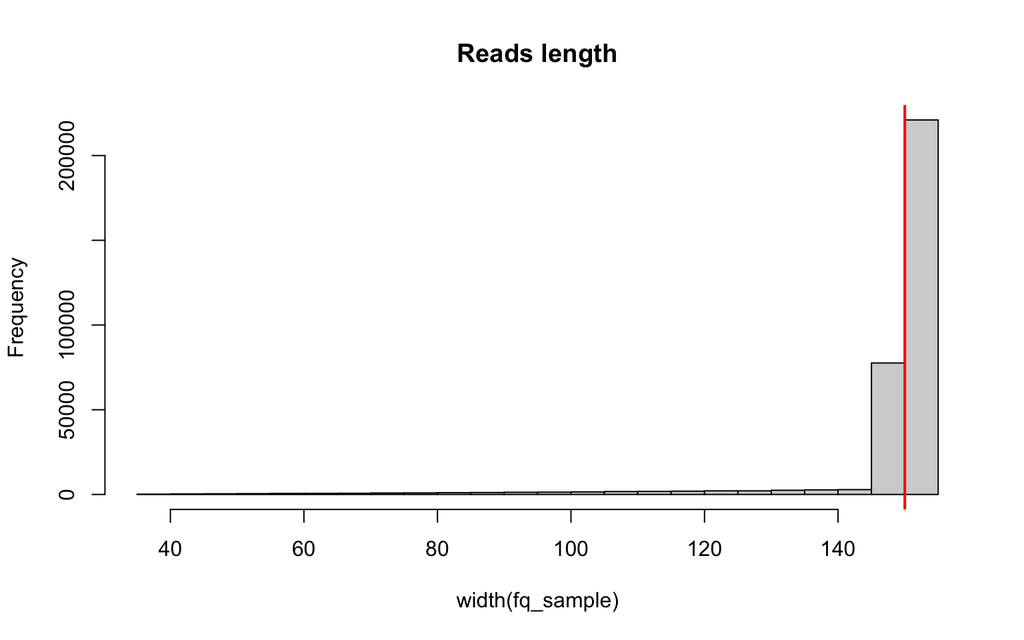

```r
hist(width(fq_sample), main = "Reads length")
abline(v = 150, col = "red", lwd = 2)
```

Podemos filtrar las lecturas que tengan un tamaño mínimo :

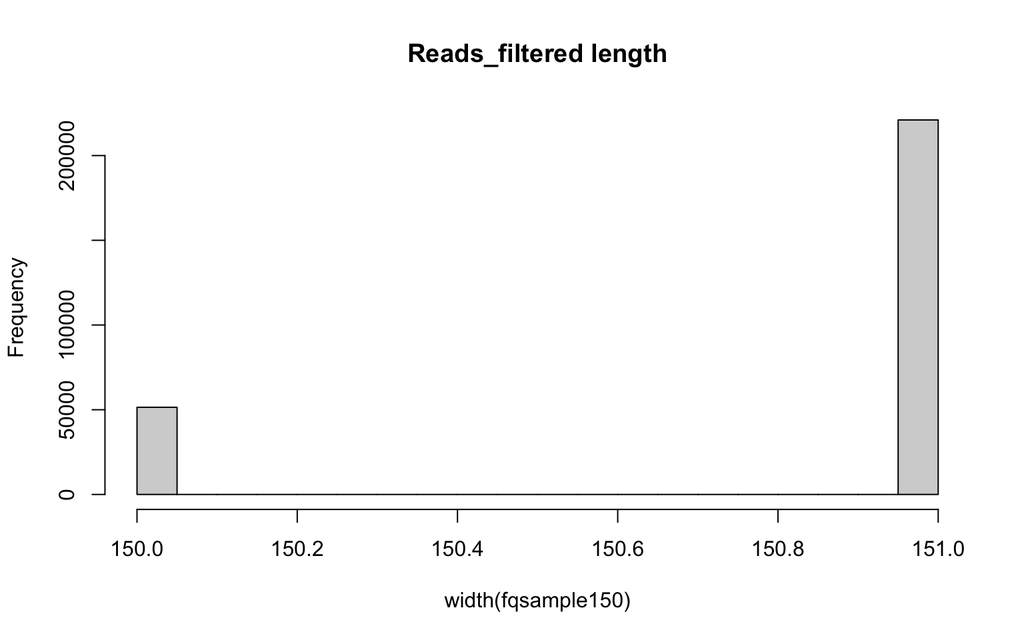

```r
fqsample150 <- fq_sample[width(fq_sample) >= 150]
hist(width(fqsample150), main = "Reads_filtered length")
```

Número de lecturas originales y lecturas filtradas por tamaño:

```r
length(fq_sample) / 1e3
```

```
## [1] 327.753
```

```r
length(fqsample150) / 1e3
```

```
## [1] 272.486
```

```
# # Write a ShortRead object
writeFasta(object = fqsample150, file = "sreads/results/reads150.fastq")
```

#### Quality assessment

```r
# get quality scores per base (for all sequences in the fastq files!) as a matrix
qPerBase = as(quality(fq_sample), "matrix")
```

Ahora podemos repasar la calidad de una o de varias secuencias. Por ejemplo, los primeros 20 nucleótidos de las 3 primeras lecturas que aparecen en el fichero .fastq:

(Remember : a score of 30 is considered a good quality as it means the accuracy of base call is 99.9%)

```r
# Check quality of one/some sequence(s)
qPerBase[1:3, 1:20]
```

```
##      [,1] [,2] [,3] [,4] [,5] [,6] [,7] [,8] [,9] [,10] [,11] [,12] [,13] [,14]
## [1,]   32   32   32   32   32   36   36   36   36    32    36    36    36    36
## [2,]   32   32   32   32   32   36   36   36   36    36    36    36    36    36
## [3,]   32   32   32   32   32   36   36   36   36    36    36    36    36    36
##      [,15] [,16] [,17] [,18] [,19] [,20]
## [1,]    36    36    36    36    36    36
## [2,]    36    36    36    36    36    36
## [3,]    36    36    36    36    36    36
```

Podemos filtrar las lecturas que tengan una calidad mínima :

```
* por cada secuencia : sumar bases < calidad mínima
* extraer las secuencias donde el paso anterior  = 0
```

```r
# get number of bases per read that have quality score below 20
qcount = rowSums(qPerBase <= 30, na.rm = TRUE)

# Number of reads where all Phred scores >= 20
# qcount == 0 , meaning all quality scores per base in the read >= 20
fqsample_qfiltered = fq_sample[qcount == 0]
```

Calidad general de las lecturas : representación visual.

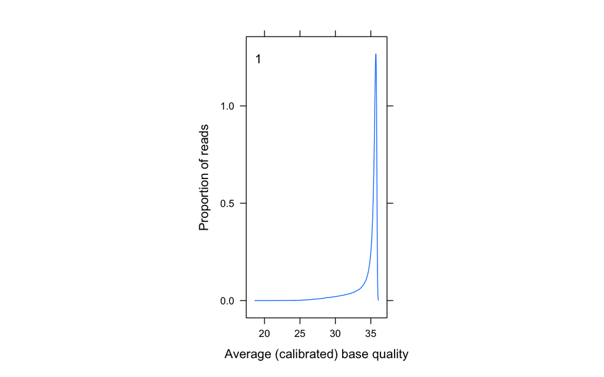

```r
#fastq original reads (non-filtered):
qaSummary = qa(fq_sample, lane = 1)
df = qaSummary[["readQualityScore"]]

#fastq filtered reads by quality
qaSummary_q = qa(fqsample_qfiltered, lane = 1)
df_q = qaSummary_q[["readQualityScore"]]

# Plotting base quality
par(mfrow=c(1,2))
ShortRead:::.plotReadQuality(df[df$type=="read",])
```

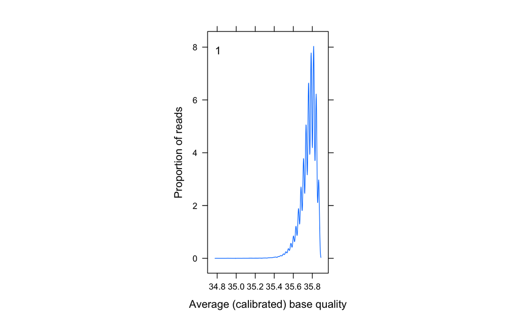

```r
ShortRead:::.plotReadQuality(df_q[df$type=="read",])
```

(Lanes with consistently good quality reads have strong peaks at the right of the panel).

De nuevo, podemos escribir en formato fastq el objeto de clase `ShortReadQ` que contiene las lecturas filtradas con la calidad mínima seleccionada :

```
writeFastq(object = fqsample_qfiltered,
           file = "sreads/results/reads_Qfiltered.fastq")
```

Calidad general de las lecturas : número de secuencias.

```r
# number of reads in non-filtered and filtered datasets
length(fq_sample)
```

```
## [1] 327753
```

```r
length(fqsample_qfiltered)
```

```
## [1] 63770
```

Calidad general de las lecturas : estadística descriptiva.

```r
# summaries of reads in non-filtered and filtered datasets
summary((width(fq_sample)))
```

```
##    Min. 1st Qu.  Median    Mean 3rd Qu.    Max.
##    35.0   150.0   151.0   146.9   151.0   151.0
```

```r
summary((width(fqsample_qfiltered)))
```

```
##    Min. 1st Qu.  Median    Mean 3rd Qu.    Max.
##    35.0   149.0   151.0   142.7   151.0   151.0
```

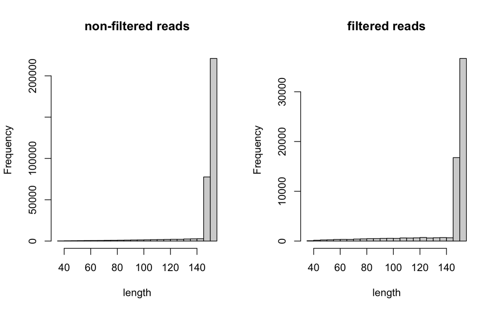

```r
# histograms of reads in non-filtered and filtered datasets
par(mfrow=c(1,2))
hist(width(fq_sample), main = "non-filtered reads", xlab = "length")
hist(width(fqsample_qfiltered), main = "filtered reads", xlab = "length")
```

## Alineamiento

```
  *Analisis de genomas y transcriptomas con plataforma NGS
  *Master Biotecnología
  *2024

  Jose V. Die, Dep Genetics, UCO
  jose.die@uco.es
```

En este módulo trabajaremos con lecturas de *Saccharomyces cerevisiae* generadas en un experimento [RNA-Seq](https://www.ncbi.nlm.nih.gov/geo/query/acc.cgi?acc=GSE133136). Las lecturas obtenidas son del tipo `paired-end reads` donde cada fragmento está secuenciado por los dos extremos, generando una estructura de ficheros de este tipo:

- FFFF_1.fastq.gz
- FFFF_2.fastq.gz

Además, trabajaremos con un formato nuevo de fichero ([.gff3](http://www.ensembl.org/info/website/upload/gff3.html)) que contiene información de anotación genómica.

Formatos ficheros :

- .FASTA (.FA,.FNA): biological sequences (eg. chromosomes)
- .FASTQ (.FQ): short-reads (eg. illumina)
- .GFF (.GFF3, .GTF): genomic elements coordinates (eg. genes)

Para completar este módulo se realizarán las siguientes tareas :

- descarga anotación genoma *S. cerevisiae* (`.gff3`)
- descarga de secuencias RNA-Seq (SRR9336468)
- descompresión de ficheros (`gz`)
- alineamiento BLAST
- genome mapping alignment
  - index the reference genome
  - align fastq files
  - convert `.sam` files into `.bam` files
- IGV : visual exploration of genomic data
- filtering reads by mapping quality

Mapeador : Bowtie2

- [publicación](https://www.nature.com/articles/nmeth.1923)
- Bowtie2 software [homepage](http://bowtie-bio.sourceforge.net/bowtie2/index.shtml)

Visualización datos genómicos : IGV

- [homepage](https://igv.org/)
- [aplicación escritorio](https://igv.org/doc/desktop/)

Instalación del paquete que usaremos en este módulo.

```r
BiocManager::install("Rbowtie2")        # <- align FASTQ files
BiocManager::install("Rsamtools")       # <- manipulate SAM files
```

Una vez instalados los paquetes necesarios para este módulo, cargamos las librerías.

```r
# Dependencies
library(Rbowtie2)
library(Rsamtools)
```

### Descarga ficheros

Estructura del proyecto

```r
# check folders - if FALSE, create the folders
dir.exists("mapping")
dir.exists("mapping/fastq")
dir.exists("mapping/genome")
dir.exists("mapping/bam")
dir("mapping")                   # see files and folders in the indicated path)
```

Descarga ficheros secuencia genómica

```
# download if the file is not in the folder
if (!file.exists("mapping/genome/Saccharomyces_cerevisiae_genome.gff3"))
download.file("https://www.dropbox.com/s/qtaret1hrbvw2xb/Saccharomyces_cerevisiae_genome.gff3.gz?dl=1",
              destfile = "mapping/genome/Saccharomyces_cerevisiae_genome.gff3.gz")
```

También necesitamos el fichero que contiene la secuencia del genoma de *S. cerevisiae* (fasta). Como lo descargamos en el módulo anterior, podemos copiarlo desde allí.

```r
file.copy(from = "sreads/genome/Saccharomyces_cerevisiae_genome.fa", to = "mapping/genome/" )
```

Descarga de secuencias cortas

```r
download.file("https://www.dropbox.com/s/v06um7vt9ojdf42/NGS_MB_SRR9336468_1.fastq.gz?dl=1",
              destfile = "mapping/fastq/1M_SRR9336468_1.fastq.gz")

download.file("https://www.dropbox.com/s/kgxfth8ra675ccu/NGS_MB_SRR9336468_2.fastq.gz?dl=1",
              destfile = "mapping/fastq/1M_SRR9336468_2.fastq.gz")
```

Descompresión de las secuencias fasta.gz y fastq.gz

```r
# Uncompress fasta.gz & fastq.gz files
#R.utils::gunzip("mapping/genome/Saccharomyces_cerevisiae_genome.fa.gz", remove=TRUE)
R.utils::gunzip("mapping/genome/Saccharomyces_cerevisiae_genome.gff3.gz", remove=TRUE)
R.utils::gunzip("mapping/fastq/1M_SRR9336468_1.fastq.gz", remove=TRUE)
R.utils::gunzip("mapping/fastq/1M_SRR9336468_2.fastq.gz", remove=TRUE)
```

En una consola LINUX podemos observar el fichero de anotación `gff3` y los ficheros `fastq`.

```
system("grep -v '#' genes/Saccharomyces_cerevisiae_genome.gff3")
```

```r
# # Total number of reads ?
system("wc -l fastq/1M_SRR9336468_1.fastq")
```

```
# # Look at the two reads from the same cDNA fragment
system("head -n 4 fastq/1M_SRR9336468_1.fastq")
```

### BLAST genome

A modo ilustrativo, vamos a alinear la primera secuencia de cada fichero contra la secuencia de referencia del genoma de *Saccharomices*.

Comenzaremos con la secuencia `@SRR9336468.1 1/2` y analizaremos en el resultado del BLAST el sitio único del alineamiento o mapeo, las coordenadas del intervalo, la coordenada de la primera base de la secuencia y la orientación de la cadena.

Del mismo modo, seguiremos con la secuencia `@SRR9336468.1 1/1`.

Run blast genome : saccharomices

### Genome mapping alignment

1. Index the reference genome

```r
# # use the indexer `bowtie2_build`
bowtie2_build(references = "mapping/genome/Saccharomyces_cerevisiae_genome.fa",
              bt2Index = "mapping/genome/Saccha_genome",
              overwrite = TRUE)
```

```r
# # create `.fai` file with `indexFa` from `Rsamtools`
indexFa("mapping/genome/Saccharomyces_cerevisiae_genome.fa")
```

2. Align `.fastq` files against the indexed genome

```r
# # align fastq files against the genome with `bowtie2`
bowtie2(bt2Index = "mapping/genome/Saccha_genome",
        samOutput = "mapping/bam/SRR9336468.sam",
        seq1 = "mapping/fastq/1M_SRR9336468_1.fastq",
        seq2 = "mapping/fastq/1M_SRR9336468_2.fastq",
        overwrite = TRUE,
        "--threads=3")


# Time difference of 2.249662 mins
```

3. Convert `.sam` files into `bam` files (more compact and indexed)

```r
# convert SAM file into BAM file (and indexes .bai) with "asBam"
asBam("mapping/bam/SRR9336468.sam")

# Time difference of 1.345935 mins
```

Una vez se tiene el `.bam`, el fichero `.sam`se puede borrar ya que los ficheros `.sam` son los más prescindibles y los que más ocupan.

```r
file.remove("mapping/bam/SRR9336468.sam")
```

### IGV

- Load genome : Genome / Local File / chromosomes / .fa + .fai
- Load genes : Tracks / Local File (gff3)
- View options
- Load reads : Tracks / Load File / select bam + index (bai)

### Filtering reads by mapping quality

Read the `.bam` file

```r
bamfile <- BamFile("mapping/bam/SRR9336468.bam")
bamfile
```

```
## class: BamFile
## path: mapping/bam/SRR9336468.bam
## index: mapping/bam/SRR9336468.bam.bai
## isOpen: FALSE
## yieldSize: NA
## obeyQname: FALSE
## asMates: FALSE
## qnamePrefixEnd: NA
## qnameSuffixStart: NA
```

```r
seqinfo(bamfile)
```

```
## Seqinfo object with 17 sequences from an unspecified genome:
##   seqnames seqlengths isCircular genome
##   I            230218       <NA>   <NA>
##   II           813184       <NA>   <NA>
##   III          316620       <NA>   <NA>
##   IV          1531933       <NA>   <NA>
##   V            576874       <NA>   <NA>
##   ...             ...        ...    ...
##   XIII         924431       <NA>   <NA>
##   XIV          784333       <NA>   <NA>
##   XV          1091291       <NA>   <NA>
##   XVI          948066       <NA>   <NA>
##   Mito          85779       <NA>   <NA>
```

Set the filter condition

```r
# # build the filtered : .bam + .bai files
param = ScanBamParam(mapqFilter = 35)     # min quality = 35 *
dest = filterBam(file = bamfile, destination = "maping/bam/mapq.bam", param = param)

# en el próximo módulo veremos que también podemos controlar la calidad del alineamiento `Deseq2` con la `featureCounts` y la variable 'minMQS'
```

Count number of alignments

```r
bamq <- BamFile("mapping/bam/mapq.bam")
countBam(bamfile)
```

```
##   space start end width           file records nucleotides
## 1    NA    NA  NA    NA SRR9336468.bam 2000000       3e+08
```

```r
countBam(bamq)
```

```
##   space start end width     file records nucleotides
## 1    NA    NA  NA    NA mapq.bam 1588056   238208400
```

Manipulating `.bam`files with `scanBam`

```r
# # scanBam generates a list (length = 1) with 13 elements
aln <- scanBam(bamfile)
aln35 = scanBam(bamq)
```

```r
# # sequence reads
aln[[1]]$seq[1:10]
aln35[[1]]$seq[1:10]
```

```r
# # mapping quality reads
aln[[1]]$mapq[1:10]
aln35[[1]]$mapq[1:10]
```

```r
# # descriptive statistics
summary(aln[[1]]$mapq)
summary(aln35[[1]]$mapq)
```

```r
# # check number of reads based on a condition
sum(aln[[1]]$mapq < 35, na.rm = TRUE)
sum(aln35[[1]]$mapq < 35, na.rm = TRUE)
```

## DEA

```
  *Analisis de genomas y transcriptomas con plataforma NGS
  *Master Biotecnología
  *2024

  Jose V. Die, Dep Genetics, UCO
  jose.die@uco.es
```

Para completar este módulo se realizarán las siguientes tareas :

- genome mapping alignment
  - index the reference genome
  - align fastq files
  - convert `.sam` files into `.bam` files
- download `.bam` files

Papers de interés:

- [Rsubread](https://academic.oup.com/nar/article/47/8/e47/5345150?login=false)
- [DESeq2](https://genomebiology.biomedcentral.com/articles/10.1186/s13059-014-0550-8)

Instalación de los paquetes que usaremos en este módulo.

```r
BiocManager::install("Rsubread")        # <- quantification of RNA-seq reads
BiocManager::install("DESeq2")          # <- method for DEA
```

Una vez instalados los paquetes necesarios para este módulo, cargamos las librerías.

```r
# Dependencies
library(Rsamtools)
library(Rsubread)
library(DESeq2)
```

### Descarga ficheros

Estructura del proyecto

```r
# check folders - if FALSE, create the folders
dir.exists("dea")
dir.exists("dea/genome")
dir.exists("dea/fastq")
dir.exists("dea/bam")
dir("dea")                   # see files and folders in the indicated path)
```

Descarga ficheros secuencia genómica

Necesitamos los ficheros de la secuencia del genoma de *S. cerevisiae* (fasta) y el fichero de anotación (.gff3) que descargamos en el módulo anterior. Podemos copiarlos desde allí.

```r
file.copy(from = "mapping/genome/Saccharomyces_cerevisiae_genome.fa", to = "dea/genome")
file.copy(from = "mapping/genome/Saccharomyces_cerevisiae_genome.fa.fai", to = "dea/genome")
file.copy(from = "mapping/genome/Saccharomyces_cerevisiae_genome.gff3", to = "dea/genome")
```

```r
dir("dea/genome")
```

```
## [1] "Saccharomyces_cerevisiae_genome.fa"
## [2] "Saccharomyces_cerevisiae_genome.fa.fai"
## [3] "Saccharomyces_cerevisiae_genome.gff3"
```

Descarga de secuencias cortas Las lecturas de secuencia corta que necesitamos son las que hemos descargado en el módulo anterior y podemos copiarlas desde allí.

```r
file.copy(from = "mapping/fastq/1M_SRR9336468_1.fastq", to = "dea/fastq")
file.copy(from = "mapping/fastq/1M_SRR9336468_2.fastq", to = "dea/fastq")
```

```r
dir("dea/fastq")
```

```
## [1] "1M_SRR9336468_1.fastq" "1M_SRR9336468_2.fastq"
```

### Genome mapping alignment

Este paso reproduce el alineamiento realizado en el módulo anterior módulo anterior con las secuencias ‘1M_SRR9336468_1.fastq’ y ‘1M_SRR9336468_2.fastq’ :

1. Index the reference genome
2. Align `.fastq` files against the indexed genome
3. Convert `.sam` file into `.bam` file

El fichero ‘SRR9336468.bam’ que genera este proceso podemos copiarlo desde el caso anterior. En esta ocasión, vamos a llamarle ‘basal_R1.bam’.

```r
file.copy(from = "mapping/bam/SRR9336468.bam", to = "dea/bam/basal_R1.bam")
file.copy(from = "mapping/bam/SRR9336468.bam.bai", to = "dea/bam/basal_R1.bam.bai")
```

Download the rest of BAM files :

```r
download.file("https://www.dropbox.com/s/iez6egp57hazmyc/bam_files.zip?dl=1",
              destfile = "dea/bam/bam_files.zip")

#Time difference of 1.007498 mins
```

Uncompress bam_files.zip

```
unzip("dea/bam/bam_files.zip",  exdir = "dea/bam" )
```

The zip file = 872.219 MB. However the dowloaded file = 659.2 MB. When the downloading step is not completed, for some reason, unzip does not work. In order to avoid problems, download the .zip file and uncompress manually.

### Gene quantification

Quantify “genes” with ``featureCounts` .

```r
# store all paths of bam files into "bamFiles" R object (use `list.files`)
bamFiles <- list.files(path = "dea/bam", pattern = "*.bam$", full.names = TRUE)
bamFiles
```

```
## [1] "dea/bam/basal_R1.bam"   "dea/bam/basal_R2.bam"   "dea/bam/basal_R3.bam"
## [4] "dea/bam/indust1_R1.bam" "dea/bam/indust1_R2.bam" "dea/bam/indust1_R3.bam"
## [7] "dea/bam/indust2_R1.bam" "dea/bam/indust2_R2.bam" "dea/bam/indust2_R3.bam"
```

```r
# quantify 'genes'

data <- featureCounts(
  files           = bamFiles,
  annot.ext       = "dea/genome/Saccharomyces_cerevisiae_genome.gff3",
  isGTFAnnotation = TRUE,
  GTF.featureType = "gene",
  GTF.attrType    = "ID",
  isPairedEnd     = TRUE,
  requireBothEndsMapped = TRUE,
  minMQS          = 30,
  strandSpecific  = 2,
  nthreads = 4)
```

[output not shown]

[output cut: 54 more lines]

```
## ||    Total alignments : 1000000                                              ||
## ||    Successfully assigned alignments : 760304 (76.0%)                       ||
## ||    Running time : 0.02 minutes                                             ||
## ||                                                                            ||
## || Process BAM file indust2_R3.bam...                                         ||
## ||    Strand specific : reversely stranded                                    ||
## ||    Paired-end reads are included.                                          ||
## ||    Total alignments : 1000000                                              ||
## ||    Successfully assigned alignments : 756364 (75.6%)                       ||
## ||    Running time : 0.02 minutes                                             ||
## ||                                                                            ||
## || Write the final count table.                                               ||
## || Write the read assignment summary.                                         ||
## ||                                                                            ||
## \\============================================================================//
```

El objeto `data` es una lista que contiene varios elementos. Las cuentas de lecturas se han almacenado en ‘counts’.

```r
names(data)
```

```
## [1] "counts"     "annotation" "targets"    "stat"
```

```r
# Extract read counts into a new object
raw_counts = data$counts

# Example : read counts for a given gene over one condition (three bio. reps)
raw_counts["gene:YAL063C", 7:9]
```

```
## indust2_R1.bam indust2_R2.bam indust2_R3.bam
##              0              0              0
```

*Exercise* : Does the mapping match what I see in IGV ?

### DESeq workflow

Como punto de partida, DESeq requiere dos objetos con la siguiente información :

- raw counts of the number of reads aligning each gene
- associated sample metadata

Comenzaremos creando una **tabla de metadatos** donde se recoja la información del experimento. Un ejemplo puede verse [aquí](https://github.com/jdieramon/master_biotec_NGS/blob/main/sample_table.md).

```r
# Create sample vector
sampleID = paste0("SRR93364", 68:76)

# Create condition vector
conditions = rep(c("basal", "indust1", "indust2"), each = 3)

# Create description vector
description = rep(c("pH5_0.04CO2", "pH5_5CO2", "pH3_0.04CO2"), each = 3)

# Create data frame
saccha_metadata <- data.frame(sampleID, conditions, description)

# Assign the row names of the data frame
rownames(saccha_metadata) = paste(conditions, paste0("R",1:3), sep = "_")

# Save the df into a csv file
dir.create("dea/data")
write.csv(saccha_metadata, file = "dea/data/saccha_metadata.csv")
```

DESeq2 requires the sample names in the metadata and counts dataset to be in the same order. Therefore, the row names in the metadata need to be in the same order as the column names of the count data (= mismo orden que los ficheros bam).

```r
# column names of the count data
colnames(raw_counts) = gsub(".bam", "",  colnames(raw_counts))

# row names of the metadata
rownames(saccha_metadata)
```

```
## [1] "basal_R1"   "basal_R2"   "basal_R3"   "indust1_R1" "indust1_R2"
## [6] "indust1_R3" "indust2_R1" "indust2_R2" "indust2_R3"
```

```r
# check identity
identical(colnames(raw_counts), rownames(saccha_metadata))
```

```
## [1] TRUE
```

```r
dds <- DESeqDataSetFromMatrix(countData = raw_counts,
                              colData = saccha_metadata,
                              design = ~ conditions)
```

**Normalize raw counts for library size**.  
The raw counts for each sample are divided by the associated sample-specific size factor for normalization. To view the size factors used for normalization, we can use the `sizeFactors` function.

```r
dds <- estimateSizeFactors(dds)
sizeFactors(dds)
```

```
##   basal_R1   basal_R2   basal_R3 indust1_R1 indust1_R2 indust1_R3 indust2_R1
##  1.0575946  1.0486980  1.2369258  1.2574809  1.0282855  1.0269234  0.9417575
## indust2_R2 indust2_R3
##  0.8067719  0.8060861
```

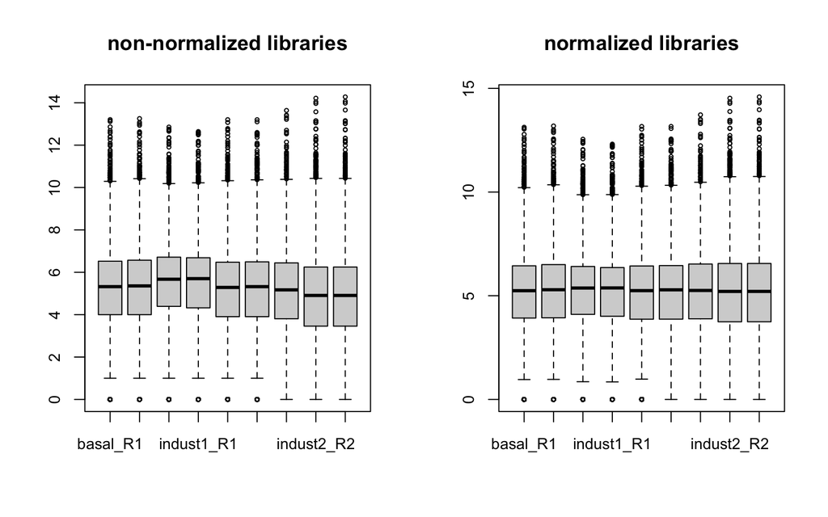

```r
norm_counts <- counts(dds, normalized = TRUE)
# Histogram
par(mfrow=c(1,2))
boxplot(log2(counts(dds, normalized = FALSE)+1),
        cex = 0.5, cex.axis = .9, main = "non-normalized libraries")
boxplot(log2(norm_counts+1), cex = 0.5, cex.axis = .9,
        main = "normalized libraries")
```

```r
par(mfrow=c(1,1))
```

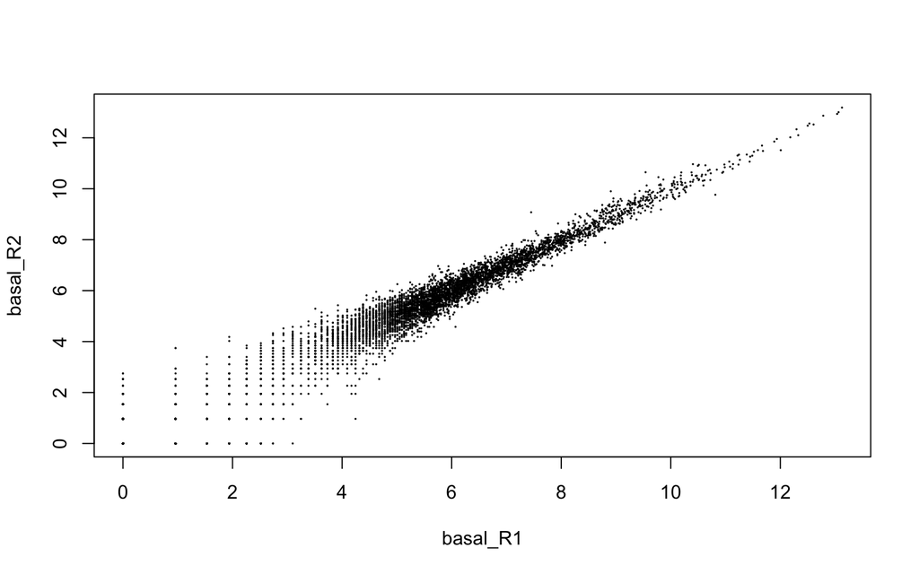

```r
# Scatterplot
log.norm.counts = log2(norm_counts + 1)
plot(log.norm.counts[,1:2], cex=.1)
```

**Unsupervised Clustering Analyses**.